# Сравнение линейных моделей

## Мы рассмотрим

- Принципы выбора лучшей линейной модели
- Переобучение моделей
- Метод максимального правдоподобия
- Сравнение линейных моделей разными способами:
  - частный F-критерий
  - тест отношения правдоподобий
  - информационный критерий Акаике (AIC)

### Вы сможете

- Объяснить связь между качеством описания существующих данных и краткостью модели
- Объяснить, что такое "переобучение" модели
- Определять, какие модели являются вложенными
- Объяснить, как подбирают параметры линейных моделей методом максимального правдоподобия
- Сравнивать вложенные модели при помощи частного F-критерия или теста отношения правдоподобий
- Сравнивать модели при помощи AIC

## Принципы выбора лучшей линейной модели

"Essentially, all models are wrong,  
but some are useful"  
Georg E. P. Box

## Важно не только тестирование гипотез, но и построение моделей

- Проверка соответствия наблюдаемых данных предполагаемой функциональной связи между зависимой перменной и предикторами:
  - оценки параметров,
  - **тестирование гипотез**,
  - оценка объясненной изменчивости (\(R^2\)),
  - анализ остатков
- **Построение моделей** для предсказания значений в новых условиях:
  - Выбор оптимальной модели
  - Оценка предсказательной способности модели **на новых данных**

## Зачем может понадобится упрощать модель?

### Какую модель можно подобрать для описания этой закономерности?

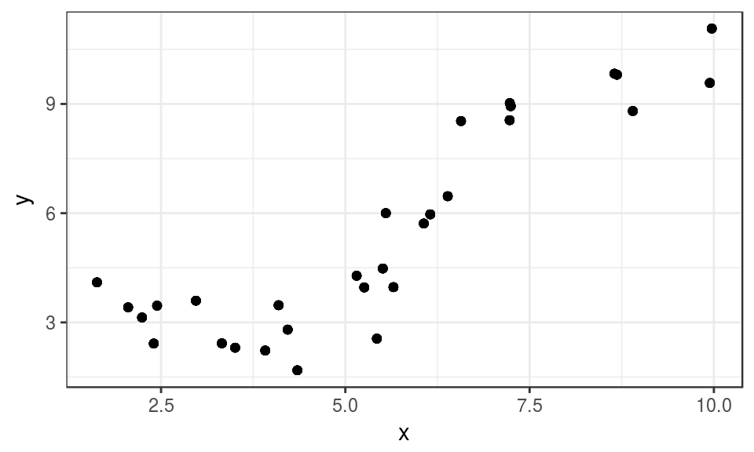

- Для этих данных можно подобрать несколько моделей. Попробуем посмотреть, как это будет выглядеть на примере loess— локальной полиномиальной регрессии. (Если интересно, [подробнее о loess-регрессии](https://www.mathworks.com/help/curvefit/smoothing-data.html#bq_6ys3-4))

## Какая из этих моделей лучше описывает данные?

На этих графиках показаны предсказания loess-регрессии для одних и тех же исходных данных.

Cложность модели — в общем случае, это число параметров. Для loess-регрессии сложность модели отражает степень сглаживания: у более сложных моделей маленькая степень сглаживания.

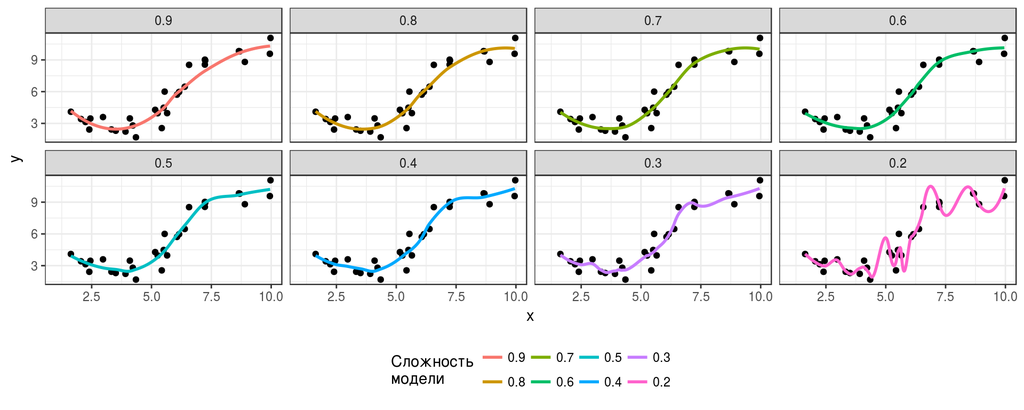

- Некоторые модели недообучены (underfitted) — слишком мало параметров, предсказания неточны.
- Другие модели переобучены (overfitted) — слишком много параметров, предсказывают еще и случайный шум.

## Что будет, если получить предсказания моделей на новых данных?

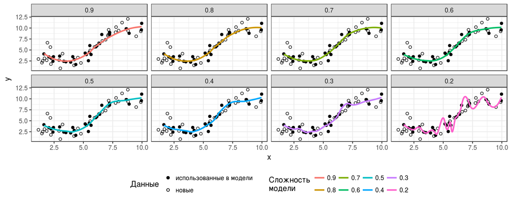

На новых данных предсказания моделей не будут идеальными.

## Как при усложнении модели меняется качество предсказаний?

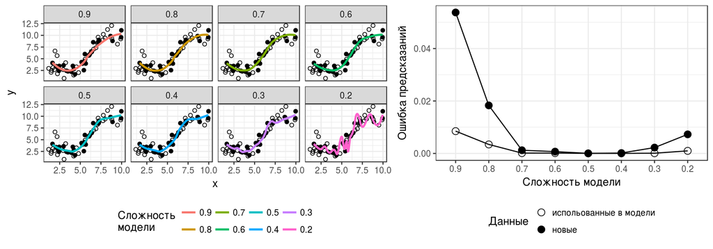

Ошибка предсказаний на новых данных практически всегда больше, чем на исходных данных. Более сложные модели лучше описывают существующие данные, но на новых данных их предсказания хуже.

При усложнении модели:

- ошибки предсказаний на исходных данных убывают (иногда, до какого-то уровня) (L-образная кривая)
- ошибки предсказаний на новых данных убывают, затем возрастают из-за переобучения (U-образная кривая)

## Погрешность и точность

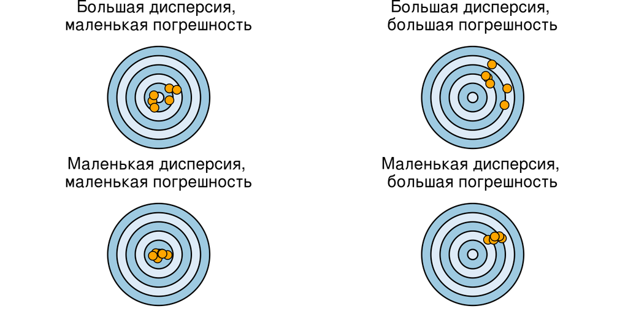

- Погрешность (accuracy, точность)— отсутствие погрешности (bias).
- Точность (precision, тоже точность — другой аспект) — разброс значений

Предсказания, сделанные на новых данных, будут отличаться от истинных значений не только из-за погрешности или неточности. Еще один источник отличий — это так называемая неснижаемая ошибка.

## Компромисс между погрешностью и разбросом значений предсказаний (Bias-Variance Tradeoff)

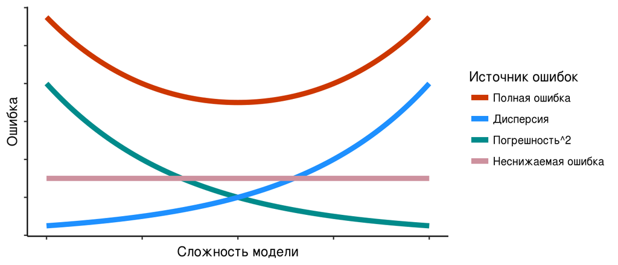

\[Полная~ошибка = Дисперсия + (Погрешность)^2 + Неснижаемая~ошибка\] При увеличении сложности модели снижается погрешность предсказаний, но возрастает их разброс. Поэтому общая ошибка предсказаний велика у недообученных или переобученных моделей, а у моделей средней сложности она будет минимальной.

## Критерии и методы выбора моделей зависят от задачи

**Объяснение закономерностей, описание функциональной зависимости**

- Нужна точность оценки параметров
- Нужны точные тесты влияния предикторов: F-тесты или тесты отношения правдоподобий (likelihood-ratio tests)

**Предсказание значений зависимой переменной**

- Нужна простая модель: "информационные" критерии (АIC, BIC, и т.д.)
- Нужна оценка качества модели на данных, которые не использовались для ее первоначальной подгонки: методы ресамплинга (кросс-валидация, бутстреп)

### Не позволяйте компьютеру думать за вас!

- Хорошая модель должна соответствовать условиям применимости, иначе вы не сможете доверять результатам тестов.
- Другие соображения: разумность, целесообразность модели, простота, ценность выводов, важность предикторов.

## Модель множественной линейной регрессии с прошлой лекции

## Пример: птицы в лесах Австралии

От каких характеристик лесного участка зависит обилие птиц в лесах юго-западной Виктории, Австралия (Loyn, 1987)

Переменных много, мы хотим из них выбрать **оптимальный небольшой** набор.

56 лесных участков:

- ABUND - обилие птиц
- AREA - площадь участка
- YRISOL - год изоляции участка
- DIST - расстояние до ближайшего леса
- LDIST - расстояние до ближайшего большого леса
- GRAZE - пастбищная нагрузка (1-5)
- ALT - высота над уровнем моря

Пример из кн. Quinn, Keugh, 2002, данные из Loyn, 1987)

## Модель из прошлой лекции

```r
bird <- read.csv("data/loyn.csv")
bird$logAREA <- log(bird$AREA)
bird$logDIST <- log(bird$DIST)
bird$logLDIST <- log(bird$LDIST)
mod2 <- lm(ABUND ~ logAREA + YRISOL + logDIST + logLDIST + ALT, data = bird)
```

## Влияют ли предикторы?

```r
summary(mod2)
```

```
##
## Call:
## lm(formula = ABUND ~ logAREA + YRISOL + logDIST + logLDIST +
##     ALT, data = bird)
##
## Residuals:
##     Min      1Q  Median      3Q     Max
## -15.439  -3.669   0.332   2.765  15.759
##
## Coefficients:
##              Estimate Std. Error t value   Pr(>|t|)
## (Intercept) -226.0006    74.2526   -3.04     0.0037 **
## logAREA        3.6882     0.5989    6.16 0.00000012 ***
## YRISOL         0.1207     0.0377    3.20     0.0024 **
## logDIST       -0.1033     1.1759   -0.09     0.9303
## logLDIST      -0.3281     0.9417   -0.35     0.7290
## ALT            0.0318     0.0235    1.36     0.1814
## ---
## Signif. codes:  0 '***' 0.001 '**' 0.01 '*' 0.05 '.' 0.1 ' ' 1
##
## Residual standard error: 6.52 on 50 degrees of freedom
## Multiple R-squared:  0.664,  Adjusted R-squared:  0.631
## F-statistic: 19.8 on 5 and 50 DF,  p-value: 7.97e-11
```

Не все предикторы влияют, возможно, эту модель можно оптимизировать…

## Сравнение линейных моделей

## Вложенные модели (nested models)

## Вложенные модели (nested models)

Две модели являются *вложенными*, если одну из них можно получить из другой путем удаления некоторых предикторов.

Удаление предиктора - коэффициент при данном предикторе равен нулю.

### Полная модель (full model)

М1: \(y _i = \beta _0 + \beta _1 x _1 + \beta _2 x _2 + \epsilon _i\)

### Неполные модели (reduced models)

М2: \(y _i = \beta _0 + \beta _1 x _1 + \epsilon _i\)

М3: \(y _i = \beta _0 + \beta _2 x _2 + \epsilon _i\)

M2 вложена в M1  
M3 вложена в M1  
M2 и M3 не вложены друг в друга

### Нулевая модель (null model), вложена в полную (M1) и в неполные (M2, M3)

\(y _i = \beta _0 + \epsilon _i\)

## Задание

Для тренировки запишем вложенные модели для данной полной модели

(1)\(y _i = \beta _0 + \beta _1 x _1 + \beta _2 x _2 + \beta _3 x _3 + \epsilon _i\)

## Решение

Для тренировки запишем вложенные модели для данной полной модели

(1)\(y _i = \beta _0 + \beta _1 x _1 + \beta _2 x _2 + \beta _3 x _3 + \epsilon _i\)

Модели:

- (2)\(y _i = \beta _0 + \beta _1 x _1 + \beta _2 x _2 + \epsilon _i\)
- (3)\(y _i = \beta _0 + \beta _1 x _1 + \beta _3 x _3 + \epsilon _i\)
- (4)\(y _i = \beta _0 + \beta _2 x _2 + \beta _3 x _3 + \epsilon _i\)
- (5)\(y _i = \beta _0 + \beta _1 x _1 + \epsilon _i\)
- (6)\(y _i = \beta _0 + \beta _2 x _2 + \epsilon _i\)
- (7)\(y _i = \beta _0 + \beta _3 x _3 + \epsilon _i\)
- (8)\(y _i = \beta _0 + \epsilon _i\)

Вложенность:

- (2)-(4)- вложены в (1)
- (5)-(7)- вложены в (1), при этом
- (5)вложена в (1), (2), (3);
- (6)вложена в (1), (2), (4);
- (7)вложена в (1), (3), (4)
- (8)- нулевая модель - вложена во все

## Частный F-критерий

## Сравнение вложенных линейных моделей при помощи F-критерия

### Полная модель

\(y _i = \beta _0 + \beta _1 x _{i1} + \ldots + \beta _k x _{ik} + \beta _p x _{ip} + \epsilon _i\)  
\(df _{reduced, full} = p\)  
\(df _{error, full} = n - p - 1\)

### Уменьшеная модель (без фактора \(\beta _p x _{ip}\))

\(y _i = \beta _0 + \beta _1 x _{i1} + \ldots + \beta _k x _{ik} + \epsilon _i\)  
\(df _{reduced, reduced} = k\)  
\(df _{error, reduced} = n - k - 1\)

### Как оценить насколько больше изменчивости объясняет полная модель, чем уменьшенная модель?

- Разница объясненной изменчивости — \(SS _{error,reduced} - SS _{error,full}\)
- С чем, по аналогии с обычным F-критерием, можно сравнить эту разницу объясненной изменчивости?
- Можно сравнить с остаточной изменчивостью полной модели — \(SS _{error, full}\)

## Сравнение вложенных линейных моделей при помощи F-критерия

### Полная модель

\(y _i = \beta _0 + \beta _1 x _{i1} + \ldots + \beta _k x _{ik} + \beta _p x _{ip} + \epsilon _i\)  
\(df _{reduced, full} = p\)  
\(df _{error, full} = n - p - 1\)

### Уменьшеная модель (без фактора \(\beta _p x _{ip}\))

\(y _i = \beta _0 + \beta _1 x _{i1} + \ldots + \beta _k x _{ik} + \epsilon _i\)  
\(df _{reduced, reduced} = k\)  
\(df _{error, reduced} = n - k - 1\)

### Частный F-критерий - оценивает выигрыш объясненной дисперсии от включения фактора в модель

\[F = \frac {(SS _{error,reduced} - SS _{error,full}) / (df _{reduced, full} - df _{reduced, reduced})} {(SS _{error, full})/ df _{error, full}}\]

## Сравнение линейных моделей при помощи частного F-критерия

Постепенно удаляем предикторы. Модели обязательно должны быть вложенными! *

### Обратный пошаговый алгоритм (backward selection)

- - 1.Подбираем полную модель
- Повторяем 2-3 для каждого из предикторов:
- 2.Удаляем один предиктор (строим уменьшенную модель)
- 3.Тестируем отличие уменьшенной модели от полной
- 4.Выбираем предиктор для окончательного удаления: это предиктор, удаление которого минимально ухудшает модель. Модель без него будет "полной" для следующего раунда выбора оптимальной модели.
- Повторяем 1-4 до тех пор, пока что-то можно удалить.
- — **Важно!** Начинать упрощать модель нужно со взаимодействий между предикторами. Если взаимодействие из модели удалить нельзя, то нельзя удалять и отдельно стоящие предикторы, из которых оно состоит. Но мы поговорим о взаимодействиях позже

## Частный F-критерий в R

## Влияют ли предикторы?

- Можем попробовать оптимизировать модель

```r
summary(mod2)
```

```
##
## Call:
## lm(formula = ABUND ~ logAREA + YRISOL + logDIST + logLDIST +
##     ALT, data = bird)
##
## Residuals:
##     Min      1Q  Median      3Q     Max
## -15.439  -3.669   0.332   2.765  15.759
##
## Coefficients:
##              Estimate Std. Error t value   Pr(>|t|)
## (Intercept) -226.0006    74.2526   -3.04     0.0037 **
## logAREA        3.6882     0.5989    6.16 0.00000012 ***
## YRISOL         0.1207     0.0377    3.20     0.0024 **
## logDIST       -0.1033     1.1759   -0.09     0.9303
## logLDIST      -0.3281     0.9417   -0.35     0.7290
## ALT            0.0318     0.0235    1.36     0.1814
## ---
## Signif. codes:  0 '***' 0.001 '**' 0.01 '*' 0.05 '.' 0.1 ' ' 1
##
## Residual standard error: 6.52 on 50 degrees of freedom
## Multiple R-squared:  0.664,  Adjusted R-squared:  0.631
## F-statistic: 19.8 on 5 and 50 DF,  p-value: 7.97e-11
```

## Частный F-критерий, 1 способ: `anova(модель_1, модель_2)`

Вручную выполняем все действия и выбираем, что можно выкинуть, и так много раз.

```r
mod3 <- update(mod2, . ~ . - logAREA)
anova(mod2, mod3)
mod4 <- update(mod3, . ~ . - YRISOL)
anova(mod2, mod4)
mod5 <- update(mod3, . ~ . - logDIST)
anova(mod2, mod5)
mod6 <- update(mod3, . ~ . - logLDIST)
anova(mod2, mod6)
mod7 <- update(mod3, . ~ . - ALT)
anova(mod2, mod7)
# Удаляем один, и потом повторяем все снова...
```

Но мы пойдем другим путем

## Частный F-критерий, 2 способ: `drop1()`

Вручную тестировать каждый предиктор с помощью `anova()` слишком долго. Можно протестировать все за один раз при помощи `drop1()`

```r
drop1(mod2, test = "F")
```

```
## Single term deletions
##
## Model:
## ABUND ~ logAREA + YRISOL + logDIST + logLDIST + ALT
##          Df Sum of Sq  RSS AIC F value     Pr(>F)
## <none>                2128 216
## logAREA   1      1614 3742 245   37.92 0.00000012 ***
## YRISOL    1       437 2565 224   10.26     0.0024 **
## logDIST   1         0 2128 214    0.01     0.9303
## logLDIST  1         5 2133 214    0.12     0.7290
## ALT       1        78 2206 216    1.84     0.1814
## ---
## Signif. codes:  0 '***' 0.001 '**' 0.01 '*' 0.05 '.' 0.1 ' ' 1
```

```r
# Нужно убрать logDIST
```

## Тестируем предикторы (шаг 2)

```r
# Убрали logDIST
mod3 <- update(mod2, . ~ . - logDIST)
drop1(mod3, test = "F")
```

```
## Single term deletions
##
## Model:
## ABUND ~ logAREA + YRISOL + logLDIST + ALT
##          Df Sum of Sq  RSS AIC F value      Pr(>F)
## <none>                2128 214
## logAREA   1      1628 3757 244   39.02 0.000000084 ***
## YRISOL    1       437 2565 222   10.48      0.0021 **
## logLDIST  1         9 2137 212    0.20      0.6532
## ALT       1        81 2209 214    1.94      0.1701
## ---
## Signif. codes:  0 '***' 0.001 '**' 0.01 '*' 0.05 '.' 0.1 ' ' 1
```

```r
# Нужно убрать logLDIST
```

## Тестируем предикторы (шаг 3)

```r
# Убрали logLDIST
mod4 <- update(mod3, . ~ . - logLDIST )
drop1(mod4, test = "F")
```

```
## Single term deletions
##
## Model:
## ABUND ~ logAREA + YRISOL + ALT
##         Df Sum of Sq  RSS AIC F value       Pr(>F)
## <none>               2137 212
## logAREA  1      2112 4248 248   51.39 0.0000000027 ***
## YRISOL   1       502 2639 222   12.23      0.00097 ***
## ALT      1       123 2260 213    2.99      0.08978 .
## ---
## Signif. codes:  0 '***' 0.001 '**' 0.01 '*' 0.05 '.' 0.1 ' ' 1
```

```r
# Нужно убрать ALT
```

## Тестируем предикторы (шаг 4)

```r
# Убрали ALT
mod5 <- update(mod4, . ~ . - ALT)
drop1(mod5, test = "F")
```

```
## Single term deletions
##
## Model:
## ABUND ~ logAREA + YRISOL
##         Df Sum of Sq  RSS AIC F value        Pr(>F)
## <none>               2260 213
## logAREA  1      2473 4732 252    58.0 0.00000000046 ***
## YRISOL   1       607 2867 224    14.2       0.00041 ***
## ---
## Signif. codes:  0 '***' 0.001 '**' 0.01 '*' 0.05 '.' 0.1 ' ' 1
```

```r
# Больше ничего не убрать
```

## Итоговая модель

```r
summary(mod5)
```

```
##
## Call:
## lm(formula = ABUND ~ logAREA + YRISOL, data = bird)
##
## Residuals:
##    Min     1Q Median     3Q    Max
## -14.96  -3.80  -0.01   4.04  16.72
##
## Coefficients:
##              Estimate Std. Error t value      Pr(>|t|)
## (Intercept) -252.1952    69.5868   -3.62       0.00065 ***
## logAREA        3.7318     0.4900    7.62 0.00000000046 ***
## YRISOL         0.1352     0.0358    3.77       0.00041 ***
## ---
## Signif. codes:  0 '***' 0.001 '**' 0.01 '*' 0.05 '.' 0.1 ' ' 1
##
## Residual standard error: 6.53 on 53 degrees of freedom
## Multiple R-squared:  0.643,  Adjusted R-squared:  0.63
## F-statistic: 47.8 on 2 and 53 DF,  p-value: 1.35e-12
```

## Задание

Проверьте финальную модель на выполнение условий применимости

Дополните этот код

```r
library()
mod_diag <- data.frame(fortify(), bird[, c()])
# 1) График расстояния Кука
ggplot(data = , aes(x = 1:, y = .cooksd)) + geom_bar(stat = "")
# 2) График остатков от предсказанных значений
gg_resid <- ggplot(data = , aes(x = , y = )) + geom_point() + geom_hline()
gg_resid
# 3) Графики остатков от предикторов в модели и нет
res_1 <- gg_resid + aes(x = logAREA)
res_2 <- gg_resid
res_3 <- gg_resid
res_4 <- gg_resid
res_5 <- gg_resid
res_6 <- gg_resid
# все графики вместе
library()
grid.arrange(res_1, res_2, nrow = 2)
# 4) Квантильный график остатков
library()
qq
```

## Решение

### 1) График расстояния Кука

- Выбросов нет

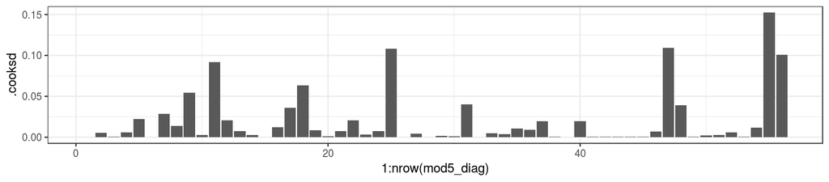

```r
mod5_diag <- data.frame(
  fortify(mod5),
  bird[, c("logDIST", "logLDIST", "GRAZE", "ALT")]
  )

ggplot(mod5_diag, aes(x = 1:nrow(mod5_diag), y = .cooksd)) +
  geom_bar(stat = "identity")
```

## Решение

### 2) График остатков от предсказанных значений

- Выбросов нет
- Гетерогенность дисперсии?
- Два наблюдения с очень большими предсказанными значениями и большими остатками. Хорошо бы проверить их.

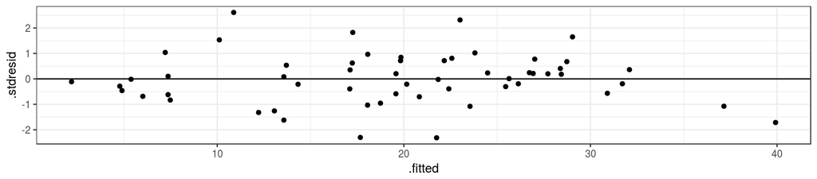

```r
gg_resid <- ggplot(data = mod5_diag, aes(x = .fitted, y = .stdresid)) +
  geom_point() + geom_hline(yintercept = 0)
gg_resid
```

## Решение

### 3) Графики остатков от предикторов в модели и нет

- Величина остатков зависит от уровня выпаса скота. Возможно, не стоило удалять эту переменную
- Есть наблюдения с экстремальными значениями предикторов (два больших леса, один далекий, один высокогорный). Хорошо бы проверить их.

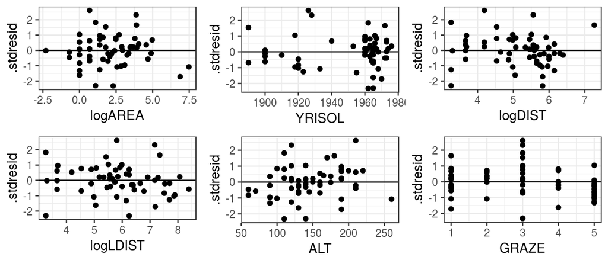

## Решение

### 3) Код для графиков остатков от предикторов в модели и нет

```r
res_1 <- gg_resid + aes(x = logAREA)
res_2 <- gg_resid + aes(x = YRISOL)
res_3 <- gg_resid + aes(x = logDIST)
res_4 <- gg_resid + aes(x = logLDIST)
res_5 <- gg_resid + aes(x = ALT)
res_6 <- gg_resid + aes(x = GRAZE)

library(gridExtra)
grid.arrange(res_1, res_2, res_3, res_4,
             res_5, res_6, nrow = 2)
```

## Решение

### 4) Квантильный график остатков

- Отклонения от нормального распределения остатков незначительны

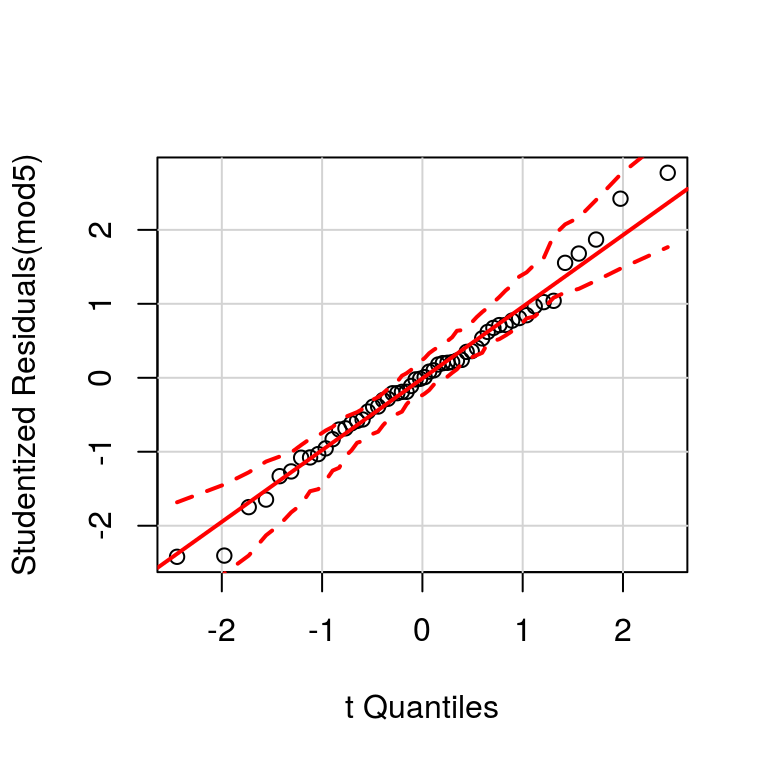

```r
library(car)
qqPlot(mod5)
```

## Описываем финальную модель

```r
summary(mod5)
```

```
##
## Call:
## lm(formula = ABUND ~ logAREA + YRISOL, data = bird)
##
## Residuals:
##    Min     1Q Median     3Q    Max
## -14.96  -3.80  -0.01   4.04  16.72
##
## Coefficients:
##              Estimate Std. Error t value      Pr(>|t|)
## (Intercept) -252.1952    69.5868   -3.62       0.00065 ***
## logAREA        3.7318     0.4900    7.62 0.00000000046 ***
## YRISOL         0.1352     0.0358    3.77       0.00041 ***
## ---
## Signif. codes:  0 '***' 0.001 '**' 0.01 '*' 0.05 '.' 0.1 ' ' 1
##
## Residual standard error: 6.53 on 53 degrees of freedom
## Multiple R-squared:  0.643,  Adjusted R-squared:  0.63
## F-statistic: 47.8 on 2 and 53 DF,  p-value: 1.35e-12
```

## Тесты отношения правдоподобий

## Вероятность и правдоподобие

Правдоподобие (likelihood) — способ измерить соответствие имеющихся данных тому, что можно получить при определенных значениях параметров модели.

Мы оцениваем это как произведение вероятностей получения каждой из точек данных

\[L(\theta| data) = \Pi^n _{i = 1}f(x| \theta)\]

где \(f(data| \theta)\) - функция плотности распределения с параметрами \(\theta\)

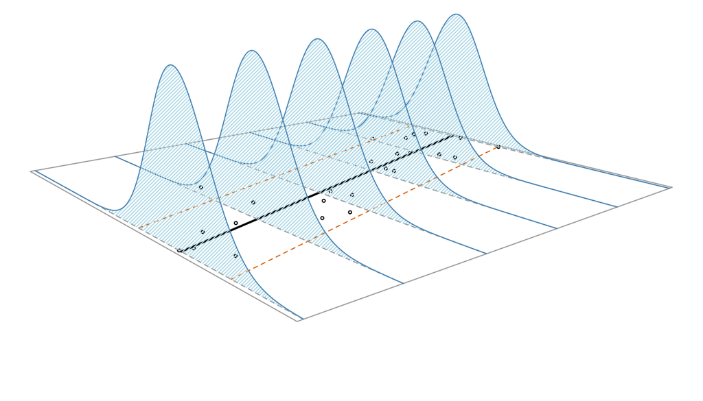

## Выводим формулу правдоподобия для линейной модели с нормальным распределением ошибок

\(y_i = \beta_0 + \beta_1x_1 + \ldots + \beta_kx_k + \epsilon_i\)

## Выводим формулу правдоподобия для линейной модели с нормальным распределением ошибок

\(y_i = \beta_0 + \beta_1x_1 + \ldots + \beta_kx_k + \epsilon_i\)

Пусть в нашей модели остатки нормально распределены (\(\epsilon_i \sim N(0, \sigma^2)\)) и их значения независимы друг от друга:

\(N(\epsilon_i; 0, \sigma^2) = \frac {1} { \sqrt {2\pi\sigma^2} } exp (-\frac {1} {2 \sigma^2} \epsilon_i^2)\)

## Выводим формулу правдоподобия для линейной модели с нормальным распределением ошибок

\(y_i = \beta_0 + \beta_1x_1 + \ldots + \beta_kx_k + \epsilon_i\)

Пусть в нашей модели остатки нормально распределены (\(\epsilon_i \sim N(0, \sigma^2)\)) и их значения независимы друг от друга:

\(N(\epsilon_i; 0, \sigma^2) = \frac {1} { \sqrt {2\pi\sigma^2} } exp (-\frac {1} {2 \sigma^2} \epsilon_i^2)\)

Функцию правдоподобия (likelihood, вероятность получения нашего набора данных) можно записать как произведение вероятностей:

\(L(\epsilon_i|\mathbf{y}, \mathbf{x}) = \Pi^n _{n = 1} N(\epsilon_i, \sigma^2) = \frac {1} {\sqrt{(2\pi\sigma^2)^n}} exp(- \frac {1} {2\sigma^2} \sum {\epsilon_i}^2)\)

## Выводим формулу правдоподобия для линейной модели с нормальным распределением ошибок

\(y_i = \beta_0 + \beta_1x_1 + \ldots + \beta_kx_k + \epsilon_i\)

Пусть в нашей модели остатки нормально распределены (\(\epsilon_i \sim N(0, \sigma^2)\)) и их значения независимы друг от друга:

\(N(\epsilon_i; 0, \sigma^2) = \frac {1} { \sqrt {2\pi\sigma^2} } exp (-\frac {1} {2 \sigma^2} \epsilon_i^2)\)

Функцию правдоподобия (likelihood, вероятность получения нашего набора данных) можно записать как произведение вероятностей:

\(L(\epsilon_i|\mathbf{y}, \mathbf{x}) = \Pi^n _{n = 1} N(\epsilon_i, \sigma^2) = \frac {1} {\sqrt{(2\pi\sigma^2)^n}} exp(- \frac {1} {2\sigma^2} \sum {\epsilon_i}^2)\)

Поскольку \(\epsilon_i = y_i - (\beta_0 + \beta_1x_1 + \ldots + \beta_kx_k)\)

то функцию правдоподобия можно переписать так:

\(L(\beta_1\ldots\beta_k, \sigma^2| \mathbf{y}, \mathbf{x}) = \frac {1} {\sqrt{(2\pi\sigma^2)^n}}exp(- \frac {1} {2\sigma^2} \sum (y_i - (\beta_0 + \beta_1x_1 + \ldots + \beta_kx_k))^2)\)

## Подбор параметров модели методом максимального правдоподобия

Чтобы найти параметры модели

\[y_i = \beta_0 + \beta_1x_1 + \ldots + \beta_kx_k + \epsilon_i\]

нужно найти такое сочетание параметров \(\beta_0\), \(\beta_1\), \(\beta_k\), и \(\sigma^2\), при котором функция правдоподобия будет иметь максимум (именно поэтому метод называется метод максимального правдоподобия:

\(\begin{array}{l} L(\beta_1\ldots\beta_k, \sigma^2| \mathbf{y}, \mathbf{x}) &= \frac {1} {\sqrt{(2\pi\sigma^2)^n}} exp(- \frac {1} {2\sigma^2} \sum {\epsilon_i}^2) = \\ &= \frac {1} {\sqrt{(2\pi\sigma^2)^n}}exp(- \frac {1} {2\sigma^2} \sum (y_i - (\beta_0 + \beta_1x_1 + \ldots + \beta_kx_k))^2) \end{array}\)

## Логарифм правдоподобия (loglikelihood)

Вычислительно проще работать с логарифмами правдоподобий (loglikelihood)

Если функция правдоподобия

\(\begin{array}{l} L(\beta_1\ldots\beta_k, \sigma^2| \mathbf{y}, \mathbf{x}) &= \frac {1} {\sqrt{(2\pi\sigma^2)^n}} exp(- \frac {1} {2\sigma^2} \sum {\epsilon_i}^2) = \\ &= \frac {1} {\sqrt{(2\pi\sigma^2)^n}}exp(- \frac {1} {2\sigma^2} \sum (y_i - (\beta_0 + \beta_1x_1 + \ldots + \beta_kx_k))^2) \end{array}\)

то логарифм правдоподобия

\(\begin{array}{l} logLik(\beta_1\ldots\beta_k, \sigma^2| \mathbf{y}, \mathbf{x}) &= & \\ ln L(\beta_1\ldots\beta_k, \sigma^2| \mathbf{y}, \mathbf{x}) &= &- \frac{n}{2} (ln2\pi + ln\sigma^2) - \frac{1}{2\sigma^2}(\sum \epsilon^2_i) = \\ &= &- \frac{n}{2} (ln2\pi + ln\sigma^2) - \\ & &- \frac{1}{2\sigma^2}(\sum (y_i - (\beta_0 + \beta_1x_1 + \ldots + \beta_kx_k))^2) \end{array}\)

Чем больше логарифм правдоподобия тем лучше модель.

## Подбор параметров модели методом максимального правдоподобия

Для подбора параметров методом максимального правдоподобия используют функцию `glm()`

```r
# Симулированные данные
set.seed(9328)
dat <- data.frame(X = runif(n = 50, min = 0, max = 10))
dat$Y <- 3 + 15 * dat$X + rnorm(n = 50, mean = 0, sd = 1)

# Подбор модели двумя способами
Mod     <-  lm(Y ~ X, data = dat) # МНК
Mod_glm <- glm(Y ~ X, data = dat) # МЛ

# Одинаковые оценки коэффициентов
coefficients(Mod)
```

```
## (Intercept)           X
##        2.95       15.02
```

```r
coefficients(Mod_glm)
```

```
## (Intercept)           X
##        2.95       15.02
```

## Логарифм правдоподобия

\(LogLik\) для модели можно найти с помощью функции `logLic()`

```r
logLik(Mod_glm)
```

```
## 'log Lik.' -65.5 (df=3)
```

## Логарифм правдоподобия вручную

```r
# Предсказанные значения
dat$predicted <- predict(Mod)
# Оценка дисперсии
SD <- summary(Mod)$sigma
# Вероятности для каждой точки
dat$Prob <- dnorm(dat$Y, mean = dat$predicted, sd = SD)
# Логарифм вероятностей
dat$LogProb <- log(dat$Prob)
# Логарифм произведения, равный сумме логарифмов
sum(dat$LogProb)
```

```
## [1] -65.5
```

## Тест отношения правдоподобий (Likelihood Ratio Test)

Тест отношения правдоподобий позволяет определить какая модель более правдоподобна с учетом данных.

\[LRT = 2ln\Big(\frac{L_1}{L_2}\Big) = 2(lnL_1 - lnL_2)\]

- \(L_1\), \(L_2\) - правдоподобия полной и уменьшенной модели
- \(lnL_1\), \(lnL_2\) - логарифмы правдоподобий

Разница логарифмов правдоподобий имеет распределение, которое можно апроксимировать \(\chi^2\), с числом степеней свободы \(df = df_2 - df_1\) (Wilks, 1938)

## Тест отношения правдоподобий в R

## Задание

Для этой полной модели

```r
GLM1 <- glm(ABUND ~ logAREA + YRISOL + logDIST + logLDIST + ALT, data = bird)
```

Подберите оптимальную модель при помощи тестов отношения правдоподобий

Тест отношения правдоподобий можно сделать с помощью тех же функций, что и частный F-критерий:

- по-одному `anova(mod3, mod2, test = "Chisq")`
- все сразу `drop1(mod3, test = "Chisq")`

## Решение (шаг 1)

```r
drop1(GLM1, test = "Chisq")
```

```
## Single term deletions
##
## Model:
## ABUND ~ logAREA + YRISOL + logDIST + logLDIST + ALT
##          Df Deviance AIC scaled dev.    Pr(>Chi)
## <none>          2128 377
## logAREA   1     3742 406       31.61 0.000000019 ***
## YRISOL    1     2565 385       10.45      0.0012 **
## logDIST   1     2128 375        0.01      0.9259
## logLDIST  1     2133 375        0.14      0.7125
## ALT       1     2206 377        2.02      0.1552
## ---
## Signif. codes:  0 '***' 0.001 '**' 0.01 '*' 0.05 '.' 0.1 ' ' 1
```

```r
# Нужно убрать logDIST
```

## Решение (шаг 2)

```r
# Убираем logDIST
GLM2 <- update(GLM1, . ~ . - logDIST)
drop1(GLM2, test = "Chisq")
```

```
## Single term deletions
##
## Model:
## ABUND ~ logAREA + YRISOL + logLDIST + ALT
##          Df Deviance AIC scaled dev.    Pr(>Chi)
## <none>          2128 375
## logAREA   1     3757 404        31.8 0.000000017 ***
## YRISOL    1     2565 383        10.5      0.0012 **
## logLDIST  1     2137 373         0.2      0.6361
## ALT       1     2209 375         2.1      0.1486
## ---
## Signif. codes:  0 '***' 0.001 '**' 0.01 '*' 0.05 '.' 0.1 ' ' 1
```

```r
# Нужно убрать logLDIST
```

## Решение (шаг 3)

```r
# Убираем logLDIST
GLM3 <- update(GLM2, . ~ . - logLDIST)
drop1(GLM3, test = "Chisq")
```

```
## Single term deletions
##
## Model:
## ABUND ~ logAREA + YRISOL + ALT
##         Df Deviance AIC scaled dev.      Pr(>Chi)
## <none>         2137 373
## logAREA  1     4248 409        38.5 0.00000000055 ***
## YRISOL   1     2639 383        11.8       0.00058 ***
## ALT      1     2260 374         3.1       0.07688 .
## ---
## Signif. codes:  0 '***' 0.001 '**' 0.01 '*' 0.05 '.' 0.1 ' ' 1
```

```r
# Нужно убрать ALT
```

## Решение (шаг 4)

```r
# Убираем ALT
GLM4 <- update(GLM3, . ~ . - ALT)
drop1(GLM4, test = "Chisq")
```

```
## Single term deletions
##
## Model:
## ABUND ~ logAREA + YRISOL
##         Df Deviance AIC scaled dev.      Pr(>Chi)
## <none>         2260 374
## logAREA  1     4732 413        41.4 0.00000000012 ***
## YRISOL   1     2867 385        13.3       0.00026 ***
## ---
## Signif. codes:  0 '***' 0.001 '**' 0.01 '*' 0.05 '.' 0.1 ' ' 1
```

```r
# Больше ничего убрать не получается
```

## Решение (шаг 5)

```r
summary(GLM4)
```

```
##
## Call:
## glm(formula = ABUND ~ logAREA + YRISOL, data = bird)
##
## Deviance Residuals:
##    Min      1Q  Median      3Q     Max
## -14.96   -3.80   -0.01    4.04   16.72
##
## Coefficients:
##              Estimate Std. Error t value      Pr(>|t|)
## (Intercept) -252.1952    69.5868   -3.62       0.00065 ***
## logAREA        3.7318     0.4900    7.62 0.00000000046 ***
## YRISOL         0.1352     0.0358    3.77       0.00041 ***
## ---
## Signif. codes:  0 '***' 0.001 '**' 0.01 '*' 0.05 '.' 0.1 ' ' 1
##
## (Dispersion parameter for gaussian family taken to be 42.6)
##
##     Null deviance: 6337.9  on 55  degrees of freedom
## Residual deviance: 2259.6  on 53  degrees of freedom
## AIC: 374
##
## Number of Fisher Scoring iterations: 2
```

Финальную модель нужно проверить на выполнение условий применимости

## Информационные критерии

## AIC - Информационный критерий Акаике (Akaike Information Criterion)

\(AIC = -2 logLik + 2p\)

- \(logLik\) - логарифм правдоподобия для модели
- \(2p\) - штраф за введение в модель \(p\) параметров, т.е. за "сложность" модели

AIC — это мера потери информации, которая происходит, если реальность описывать этой моделью (Akaike 1974)

AIC — относительная мера качества модели. Т.е. не бывает какого-то "хорошего" AIC. Значения AIC можно интерпретировать только в сравнении с AIC для других моделей: чем меньше AIC — тем лучше модель.

**Важно!** Информационные критерии можно использовать для сравнения **даже для невложенных моделей**. Но модели должны быть **подобраны с помощью ML** и **на одинаковых данных**!

## Некоторые другие информационные критерии

| Критерий | Название | Формула |
| --- | --- | --- |
| AIC | Информационный критерий Акаике | \(AIC = -2 logLik + 2p\) |
| BIC | Баесовский информационный критерий | \(BIC = -2 logLik + p \cdot ln(n)\) |
| AICc | Информационный критерий Акаике с коррекцией для малых выборок (малых относительно числа параметров: \(n/p < 40\), Burnham, Anderson, 2004) | \(AIC_c = -2 logLik + 2p + \frac{2p(p + 1)}{n - p - 1}\) |

- \(logLik\) - логарифм правдоподобия для модели
- \(p\) - число параметров
- \(n\) - число наблюдений

## Информационные критерии в R

## Рассчитаем AIC для наших моделей

```r
AIC(GLM1, GLM2, GLM3, GLM4)
```

```
##      df AIC
## GLM1  7 377
## GLM2  6 375
## GLM3  5 373
## GLM4  4 374
```

- Судя по AIC, лучшая модель GLM3 или GLM4. Если значения AIC различаются всего на 1-2 единицу — такими различиями можно пренебречь и выбрать более простую модель (GLM4).
- Уравнение модели: \(ABUND = - 252.20 + 3.73logAREA + 0.14YRISOL\)

## Недостатки и ограничения методологии отбора моделей

- Разные способы подбора оптимальной модели могут приводить к разным результатам. Не важно, какой из способов выбрать, но важно сделать это заранее, **до анализа**, чтобы не поддаваться соблазну подгонять результаты.
- При выборе моделей на основании F-тестов или тестов отношения правдоподобий приходится делать множество тестов, поэтому увеличивается риск ошибок I рода (подробнее на занятии про дисперсионный анализ). Чтобы хоть как-то себя обезопасить, лучше не включать в модель все подряд — только самое необходимое.
- Оптимальную модель лучше применять для тестирования гипотез на независимых данных, иначе получаются заниженные стандартные ошибки и завышенные эффекты. Обычно эту проблему игнорируют, но если у вас есть возможность, лучше сделать хотябы кросс-валидацию.
- Какой-то одной "лучшей" модели, как правило, не существует.

## Take-home messages

- Модели, которые качественно описывают существующие данные включают много параметров, но предсказания с их помощью менее точны из-за переобучения
- Для выбора оптимальной модели используются разные критерии в зависимости от задачи
- Сравнивая модели можно отбраковать переменные, включение которых в модель не улучшает ее
- **Метод сравнения моделей нужно выбрать заранее, еще до анализа**

## Что почитать

- Must read paper! Zuur, A.F. and Ieno, E.N., 2016. A protocol for conducting and presenting results of regression‐type analyses. Methods in Ecology and Evolution, 7(6), pp.636-645.
- Кабаков Р.И. R в действии. Анализ и визуализация данных на языке R. М.: ДМК Пресс, 2014
- Zuur, A., Ieno, E.N. and Smith, G.M., 2007. Analyzing ecological data. Springer Science & Business Media.
- Quinn G.P., Keough M.J. 2002. Experimental design and data analysis for biologists
- Logan M. 2010. Biostatistical Design and Analysis Using R. A Practical Guide